# Unsupervised Machine Learning

Introduction to Unsupervised Learning

**1.** CSV file `parliament2015.csv` contains the number of votes in the Catalan parliament elections of 2015 by municipalities. Load the dataset.

- Cluster municipalities according to the proportions of votes to each party. Describe the characteristics of each cluster.
- Fit a self-organizing map to the data. Tune parameters $r$ and $\alpha$ to obtain a good fit.

**2.** Files `Kmeans_class.R` and `Kmeans_class.py` contain an incomplete $K$-means class implementation for R and Python. Complete the definition for two main steps, *assigment_step()* and *updating_step()*, of the algorithm. The available class has different methods:

- Initialization function. It receives training data and the number of clusters.
- `set_center()`. It receives the initial centroids.
- `assignment_step()` (*not implemented*). Should assign each example to its closest cluster.
- `updating_step()` (*not implemented*). Should update the centroids according to the current assignment.
- `sequential_step()` (*not implemented*). Should update the closest centroids to a given example.
- `plot()`. It plots the current assignment, showing only the two first principal components of data.

They should allow you to execute the $K$-means algorithm step-by-step:

#### R

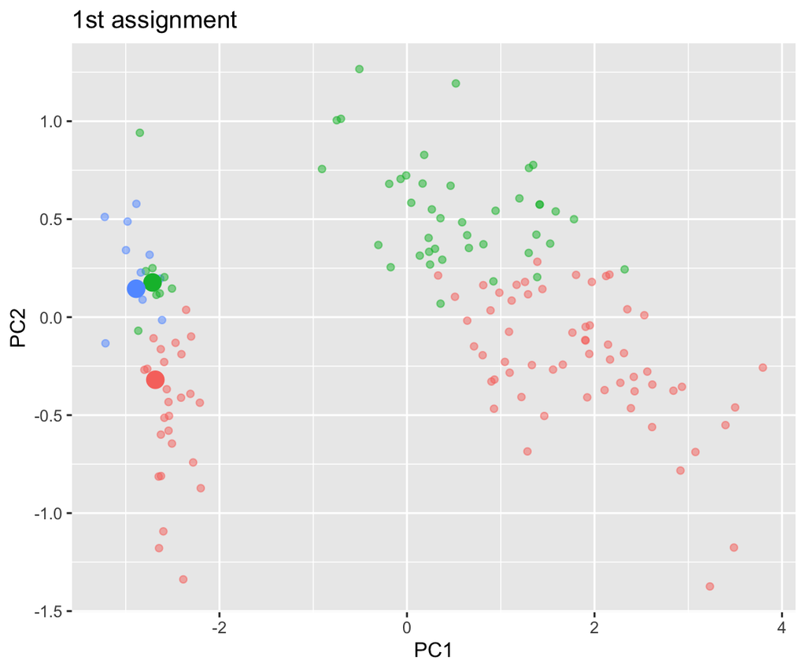

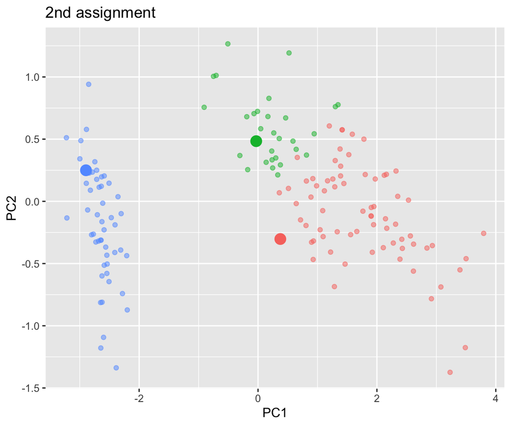

```r
source('kmeans_class.R')

X = iris[,1:4]

set.seed(1)
K = 3
km = Kmeans$new(X, K = K)

S0 = X[1:3,]

km$set_centers(S0)
km$assignment_step()$plot("1st assignment")
km$updating_step()$assignment_step()$plot("2nd assignment")
```

#### Python

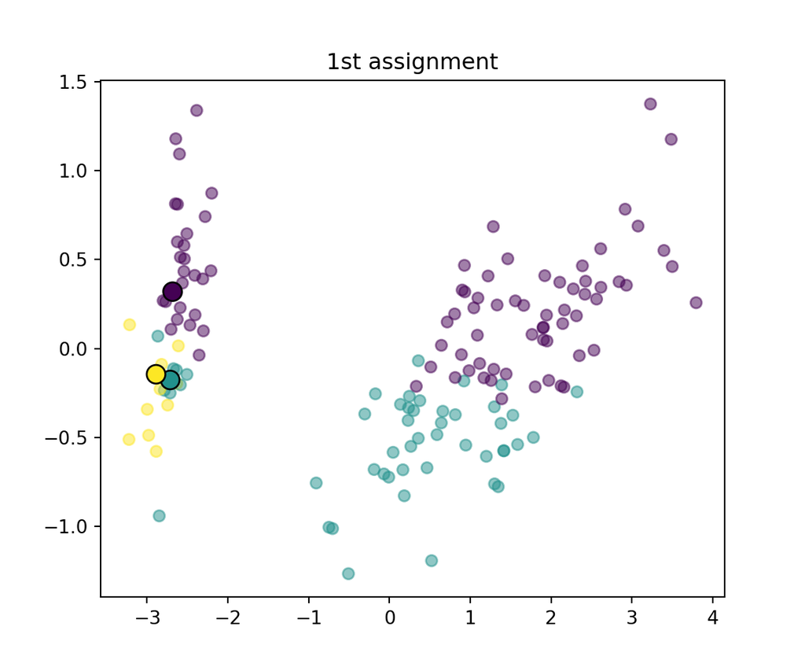

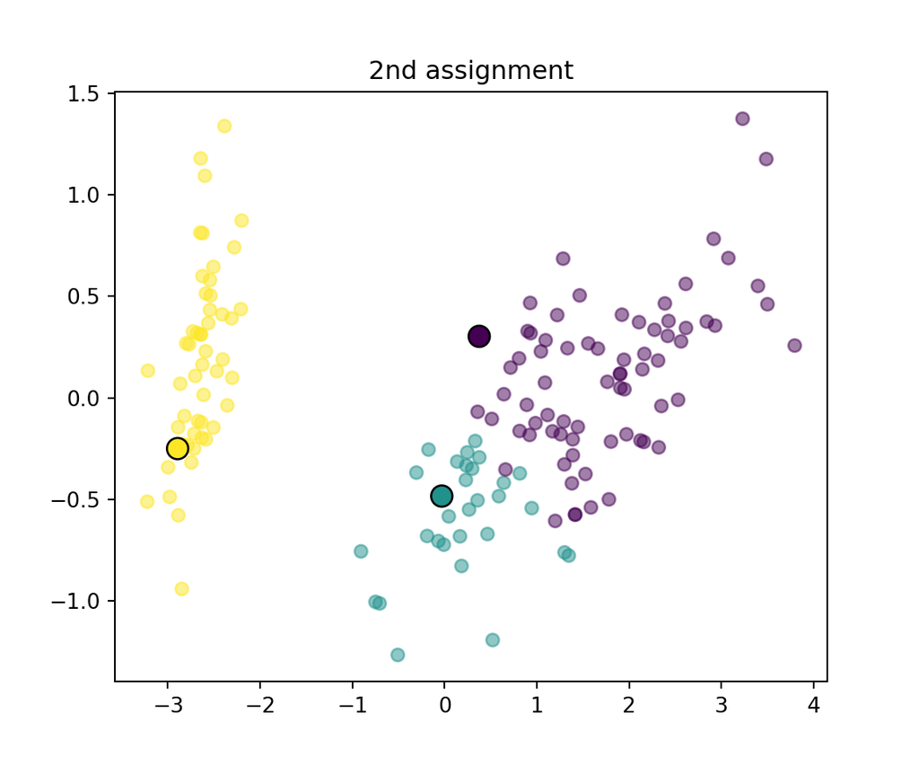

```python
import numpy as np

exec(open('kmeans_class.py').read())

X = datasets.load_iris().data
np.random.seed(1)
K = 3
km = Kmeans(X, K)

S0 = X[(0,1,2),:]

km = km.set_centers(S0)
km = km.assignment_step()
km.plot("1st assignment")
km = km.updating_step().assignment_step()
km.plot("2nd assignment")
```

**3.** A useful algorithm to calculate the mean $\bar{\textbf{x}}_n$ for the first $n$ elements of a set of examples $\textbf{x}_1, \dots, \textbf{x}_N$ is given by

$$\bar{\textbf{x}}_n = \left\{
\begin{array}[ll]\\
\textbf{x}_1&\text{if } n=1\\
\bar{\textbf{x}}_{n-1} + \frac{1}{n}(\textbf{x}_n - \bar{\textbf{x}}_{n-1})&\text{if } n>1
\end{array}
\right.$$

- Implement function *sequential_step(x, alpha)* to update the closest centroids to a given example $\textbf{x}$ passing learning rate, $\alpha$, as parameter. With the implemented function, we can calculate the mean of a sample as

#### R

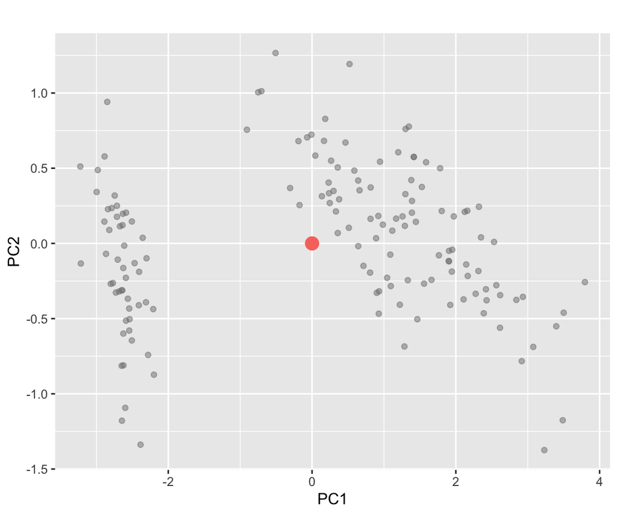

```r
mean_ = Kmeans$new(X, K = 1)
mean_$set_centers(X[1,])
for(i in 1:nrow(X)){
  x = X[i,]
  mean_$sequential_step(x, 1/i)
}
mean_$plot()
```

#### Python

```
## <__main__.Kmeans object at 0x11eaa3110>
```

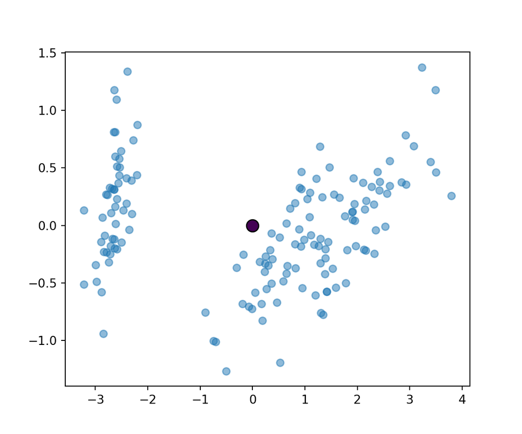

```python
mean_ = Kmeans(X, K = 1)
mean_.set_centers(np.array([X[0,:]]))
for i in range(X.shape[0]):
  x = X[i,:]
  mean_ = mean_.sequential_step(x, 1/(i+1))

mean_.plot()
```

- See that the position of the centroid is the same as the average of sample `X`.

**5** [*Columbia University Image Library (COIL-20)*](https://www.cs.columbia.edu/CAVE/software/softlib/coil-20.php) contains a database with black and white images of 20 objects seen from different angles. In this exercise we will work with the processed images: http://www.cs.columbia.edu/CAVE/databases/SLAM_coil-20_coil-100/coil-20/coil-20-proc.zip

- Object 4 consists of 72 png images of a Maneki-neko (Japanese cat) seen from different angles with a resolution of 128x128 pixels.
- Import the 72 images into R or Python.
- Create a matrix $M$ with 72 rows and 16384 columns, where each row contains the pixels of each image.
- Apply Principal Component Analysis to matrix $M$ and plot the first two components. - Propose a dimensionality reduction to be used by SOM.
- Plot the images given by the weight’s of the units.